# ¶ S5 Efectos de la climatología (frío y calor) en el Desempeño Académico ¶

¶ Estadística y Probabilidad 1 ¶

¶ 25 de noviembre del 2022 ¶

# **1. Introducción**:

## 1.1 Relevancia:

El clima presenta diversos efectos en las personas. Esto puede variar su comportamiento, así como el rendimiento que tiene frente a las actividades que realiza. En tal sentido, se busca evaluar el impacto que tiene la misma frente al rendimiento académico de los estudiantes de UTEC. De esa forma, se pueden tomar decisiones respecto a los resultados y buscar o mantener las medidas frente a los diversos cambios de clima. Un estudio de la universidad de Harvard mostró que el calor afecta el rendimiento de los estudiantes, alegando que induce a una concentración más baja (BBC, 2018) ([enlace del estudio](https://www.bbc.com/mundo/noticias-44316754)).Este proyecto se encarga de analizar los posibles factores que alteran los resultados académicos en los estudiantes de la UTEC dado que la ubicación del campus está sometida a diferentes variaciones climáticas a lo largo del año. La información climática se tomó del software [Power Larc Nasa](https://power.larc.nasa.gov/data-access-viewer/). En primer lugar se escogieron 2 cursos de diferentes áreas: Introducción a la Mecánica (Ciencias) y Comunicación 2 (Humanidades). Con la elección de curso, se buscó en el sílabus de cada una de ellas las fechas de las evaluaciones, tanto el parcial como el final. La fecha del parcial de ambas evaluaciones fue el 09/05/2022, y la fecha del final fue el 04/07/2022. A partir de esa información, se buscó en el software la temperatura correspondiente, teniendo así que para el parcial se tuvo un 19°C y para el final un 13°C. Nuestros objetivos son los siguientes :

## 1.2 Objetivos Generales:

- Determinar el efectos de la climatología (frío y calor) en el Desempeño Académico de los estudiantes de la Universidad de Ingeniería y Tecnología
- Determinar los factores que influyeron en las evaluaciones de 2 cursos de diferentes áreas: Introducción a la Mecánica (Ciencias) y Comunicación 2 (Humanidades)en los estudiantes de la Universidad de Ingeniería y Tecnología
- Analizar la temperatura correspondiente al rendir sus evaluaciones parciales y finales en cursos de Ciencias y Humanidades de los estudiantes de la Universidad de Ingeniería y Tecnología

## 1.3 Objetivos Específicos:

- Comparar las notas tanto del parcial como del final en los estudiantes de la Universidad de Ingeniería y Tecnología
- Determinar la referencia del Clima para dar una evaluación en los estudiantes de la Universidad de Ingeniería y Tecnología
- Determinar cómo afecta el calor en la concentración en los estudiantes de la Universidad de Ingeniería y Tecnología
- Determinar cómo afecta el frío en la concentración en los estudiantes de la Universidad de Ingeniería y Tecnología
- Determinar las medidas para enfrentar el frío en una evaluación en los estudiantes de la Universidad de Ingeniería y Tecnología
- Determinar las medidas para enfrentar el calor en una evaluación en los estudiantes de la Universidad de Ingeniería y Tecnología
- Determinar las sensaciones que genera el calor en una evaluación en los estudiantes de la Universidad de Ingeniería y Tecnología
- Determinar las sensaciones que genera el frío en una evaluación en los estudiantes de la Universidad de Ingeniería y Tecnología

## 1.4 Planificación:

```r
if(!require(ggplot2)){install.packages('ggplot2')}
```

### ……………………………………………………………………………………………………

# **2.Datos**:

## 2.2 Población, muestra y muestreo :

- **Población de estudio:** Estudiantes de UTEC con matrícula vigente en el año 2022-2
- **Unidad muestral:** Estudiantes de tercer ciclo de UTEC ingresantes en el año 2021-2 que pertenecen a diferentes carreras.
- **Tamaño de la muestra:** 200 estudiantes del tercer ciclo
- **Tipo de muestreo:** El tipo de muestreo que se seleccionó fue no probabilístico por conveniencia

## 2.3 Variables:

- Variables de estudio

  - | Variable | Tipo | Escala | Restricción |
    | --- | --- | --- | --- |
    | Edad (E) | Numérica | Discreta | Solo se puede digitar números enteros positivos entre 15 y 30 |
    | Género (G) | Categórica | Nominal | Solo puede marcar las opciones dadas |
    | Carrera (C) | Categórica | Nominal | Solo puede marcar las opciones dadas |
    | Nota del examen parcial de comunicación (NPC) | Numérica | Discreta | Solo se puede digitar números positivos entre 0 y 20 |
    | Nota del examen final de comunicación (NFC) | Numérica | Discreta | Solo se puede digitar números positivos entre 0 y 20 |
    | Concentración en calor (CC) | Categórica | ordinal | Solo se puede elegir una opción de la escala |
    | Concentración en frío (CF) | Categórica | ordinal | Solo puede marcar las opciones dadas |
    | Medidas en frío (MF) | Categórica | Nominal | Solo se digita texto máximo 10 palabras |
    | Medidas en calor (MC) | Categórica | Nominal | Solo se digita texto máximo 10 palabras |
    | Nota del examen parcial de Introducción a la Mecánica (NPIM) | Numérica | Discreta | Solo se puede digitar números positivos entre 0 y 20 |
    | Nota del examen final d e Introducción a la Mecánica (NFIM) | Numérica | Discreta | Solo se puede digitar números positivos entre 0 y 20 |
    | Preferencia de clima (PC) | Categórica | Nominal | Solo elegir dos dos opciones entre “Frío o calor” |
    | Mejora de estudio con calefacción (MEC) | Categórica | ordinal | Solo se puede elegir una opción de la escala |
    | Mejora de estudio con aire acondicionado (MEA) | Categórica | ordinal | Solo se puede elegir una opción de la escala |
    | Sensación con calor (SC) | Categórica | ordinal | Solo se digita texto máximo 10 palabras |
    | Sensación con frío (SF) | Categórica | ordinal | Solo se digita texto máximo 10 palabras |
    | Toma examen de comunicación en universidad (TECU) | Categórica | Nominal | Solo se puede elegir dos opciones entre “si o no” |
    | Toma examen de Intro a la mecánica en universidad (TEIMU) | Categórica | Nominal | Solo se puede elegir dos opciones entre “si o no” |

## 2.4 Limpieza de base de datos:

- Para la instalación de paquetes, usamos el siguiente comando para asegurar que cualquier máquina pueda compilarlo:

“if(!require()){install.packages(’’)}”

- Luego, llamamos a las respectivas librerías:

```r
library(readr)
library(dplyr)
library(modeest)
```

```r
library(ggplot2)
library(DescTools)
library(tidyverse)
library(ggthemes)
library(descr)
library(fastGraph)
```

- Posteriormente, introducimos nuestra base de datos al R:

```r
Clima<- read_csv("Datos.csv")
```

- Ahora detectamos si se tienen datos incompletos en la data. Además, verificamos si la tenemos todos los datos completos:

```r
sum(is.na(Clima)) #is.na() -> este comando detecta los datos incompletos; sum -> sumar
```

```
## [1] 0
```

```r
sum(!is.na(Clima)) #!is.na() -> es la negación de is.na, es decir, indica los datos completos.
```

```
## [1] 4579
```

- Al descargar la data del forms, por defecto crea una variable llamada “Marca Temporal”. Como esa variable no aporta al estudio, lo eliminamos:

```r
Clima %>% select(-1) -> Clima1
```

- A continuación, verificamos los nombres de las variables:

```r
names(Clima1)
```

```
##  [1] "Ingresa tu Edad (en años, y en números enteros):"
##  [2] "Selecciona tu Carrera Universitaria:"
##  [3] "Selecciona tu Género:"
##  [4] "¿Te cuesta concentrarte al rendir una evaluación académica cuando hace mucho CALOR? [¿Cuánto te afecta?]"
##  [5] "¿Te cuesta concentrarte al rendir una evaluación académica cuando hace mucho FRÍO? [¿Cuánto te afecta?]"
##  [6] "¿Qué medidas tomas cuando tienes una evaluación y hace mucho CALOR?"
##  [7] "¿Qué medidas tomas cuando tienes una evaluación y hace mucho FRÍO?"
##  [8] "Cuando prefieres dar una evaluación. ¿Cuándo hace FRÍO o CALOR?"
##  [9] "¿Crees que tu rendimiento académico mejoraría al incluir un sistema de aire acondicionado en las aulas en época de mucho CALOR? [¿Mejoraría?]"
## [10] "¿Crees que tu rendimiento académico mejoraría al incluir un sistema de calefacción en las aulas en época de mucho FRÍO? [¿Mejoraría?]"
## [11] "¿Qué sensación te produce al estar en un ambiente CALUROSO y tener clase o examen en ella?"
## [12] "¿Qué sensación te produce al estar en un ambiente FRÍO y tener clase o examen en ella?"
## [13] "Rendiste tu examen parcial de Introducción a la Mecánica en la Universidad:"
## [14] "Nota de tu examen parcial de Introducción a la Mecánica:"
## [15] "Rendiste tu examen parcial de Laboratorio de Comunicación 2 en la Universidad:"
## [16] "Nota de tu examen final de Introducción a la Mecánica:"
## [17] "Nota de tu examen parcial de Laboratorio de Comunicación 2:"
## [18] "Nota de tu examen final de Laboratorio de Comunicación 2:"
```

- Como los nombres son muy largos, los renombramos a palabras clave:

```r
colnames(Clima1)[1:18] <- c("E","C","G","CC","CF","MC","MF","PC","MEA","MEC","SC","SF","TEIMU","NPIM","TECU","NFIM","NPC","NFC")
```

- Asimismo, nuestro estudio solo contempla a las personas que hayan dado su examen parcial en la Universidad. Para ello, filtramos la información y eliminamos las observaciones que no cumplan con dicho requisito:

```r
Clima1[Clima1$TEIMU=="Si", ] -> Clima2
```

- Por otro lado, verificamos que los datos no tengan valores repetidos. De tenerlos los cambiamos. Iniciamos con las notas del parcial de intro a mecánica:

```r
unique(Clima2$NPIM)
```

```
##  [1] "10"   "0"    "13"   "11"   "17"   "18"   "07"   "15"   "6"    "12"
## [11] "7"    "20"   "0000" "8"    "09"   "9"    "00"   "16"   "14.5" "08"
## [21] "14"   "5"    "1"    "4"
```

```r
Clima2 %>% mutate(NPIM=
         ifelse(NPIM=="07","7",
         ifelse(NPIM=="09","9",
         ifelse(NPIM=="14.5","15",
         ifelse(NPIM=="08","8",
         ifelse(NPIM %in% c("0000","00"),"0", NPIM
         )))))) -> Clima2
```

- Luego, con las notas del final de intro a mecánica:

```r
unique(Clima2$NFIM)
```

```
##  [1] "10"   "0"    "16"   "13"   "14"   "9"    "15"   "09"   "2"    "7"
## [11] "12"   "4"    "6"    "20"   "0000" "1"    "05"   "11"   "5"    "00"
## [21] "8"    "03"   "18"   "3"    "17"
```

```r
Clima2 %>% mutate(NFIM=
         ifelse(NFIM=="09","9",
         ifelse(NFIM=="03","3",
         ifelse(NFIM=="05","5",
         ifelse(NFIM %in% c("0000","00"),"0", NFIM
         ))))) -> Clima2
```

- Luego, con las notas del parcial de comunicación:

```r
unique(Clima2$NPC)
```

```
##  [1] "11"  "16"  "14"  "0"   "17"  "15"  "20"  "13"  "08"  "12." "18"  "12"
## [13] "10"  "19"  "00"  "9"   "6"   "5"
```

```r
Clima2 %>% mutate(NPC=
         ifelse(NPC=="08","8",
         ifelse(NPC=="12.","12",
         ifelse(NPC=="00","0", NPC
         )))) -> Clima2
```

- Luego, con las notas del final de comunicación:

```r
unique(Clima2$NFC)
```

```
##  [1] "10" "16" "18" "15" "0"  "13" "17" "12" "11" "14" "00" "20" "8"  "19" "6"
```

```r
Clima2 %>% mutate(NFC=
         ifelse(NFC=="00","0", NFC
         )) -> Clima2
```

- Asimismo, verificamos que las variables correspondan a su tipo respectivo:

```r
str(Clima2)
```

```
## tibble [200 x 18] (S3: tbl_df/tbl/data.frame)
##  $ E    : num [1:200] 21 20 21 20 18 18 19 20 18 23 ...
##  $ C    : chr [1:200] "Civil" "Ambiental" "Electrónica" "Química" ...
##  $ G    : chr [1:200] "Masculino" "Femenino" "Masculino" "Femenino" ...
##  $ CC   : chr [1:200] "Me afecta y de forma considerable" "Me afecta pero puedo lidiarlo" "Me afecta en ciertas ocasiones" "Me afecta a tal punto de alterar mi concentración por completo" ...
##  $ CF   : chr [1:200] "Me afecta pero puedo lidiarlo" "Me afecta pero puedo lidiarlo" "Me afecta a tal punto de alterar mi concentración por completo" "Me afecta pero puedo lidiarlo" ...
##  $ MC   : chr [1:200] "Ropa ligera" "Ropa ligera" "Nada" "Pequeño ventilador" ...
##  $ MF   : chr [1:200] "Usar abrigo" "Usar abrigo" "Usar abrigo" "Usar abrigo" ...
##  $ PC   : chr [1:200] "Cuando hace frío" "Cuando hace frío" "Cuando hace frío" "Cuando hace frío" ...
##  $ MEA  : chr [1:200] "Mejoraría en un pequeño porcentaje" "Mejoraría en un pequeño porcentaje" "Me mantendría muy activo académicamente" "Me mantendría muy activo académicamente" ...
##  $ MEC  : chr [1:200] "Mejoraría de forma considerable" "Mejoraría de forma considerable" "Mejoraría de forma considerable" "Mejoraría de forma considerable" ...
##  $ SC   : chr [1:200] "Sueño" "Incomodidad" "Cansancio" "Sueño" ...
##  $ SF   : chr [1:200] "Incomodidad" "Sueño" "Muy activo" "Muy activo" ...
##  $ TEIMU: chr [1:200] "Si" "Si" "Si" "Si" ...
##  $ NPIM : chr [1:200] "10" "0" "13" "11" ...
##  $ TECU : chr [1:200] "Si" "Si" "Si" "Si" ...
##  $ NFIM : chr [1:200] "10" "0" "16" "13" ...
##  $ NPC  : chr [1:200] "11" "16" "14" "14" ...
##  $ NFC  : chr [1:200] "10" "16" "18" "15" ...
```

- Como las notas están en tipo char, los cambiamos a tipo int:

```r
Clima2$NPIM= as.numeric(Clima2$NPIM)
Clima2$NFIM= as.numeric(Clima2$NFIM)
Clima2$NPC= as.numeric(Clima2$NPC)
Clima2$NFC= as.numeric(Clima2$NFC)
```

En resumen, se realizó una limpieza exhaustiva, analizando cada fila y columna, tomando días para el grupo la limpieza de datos para tener buenos resultados en el análisis y descripción de cada una de las variables.

### ……………………………………………………………………………………………………

# **3. Análisis descriptivo** :

## 3.1. Descriptores numéricos:

Primero realizaremos un análisis univariado de nuestras variables a estudiar, esto con el fin de evitar sesgos y verificar si tenemos datos atípicos para que a partir de ello sacar nuestros descriptores.

### a. Edad:

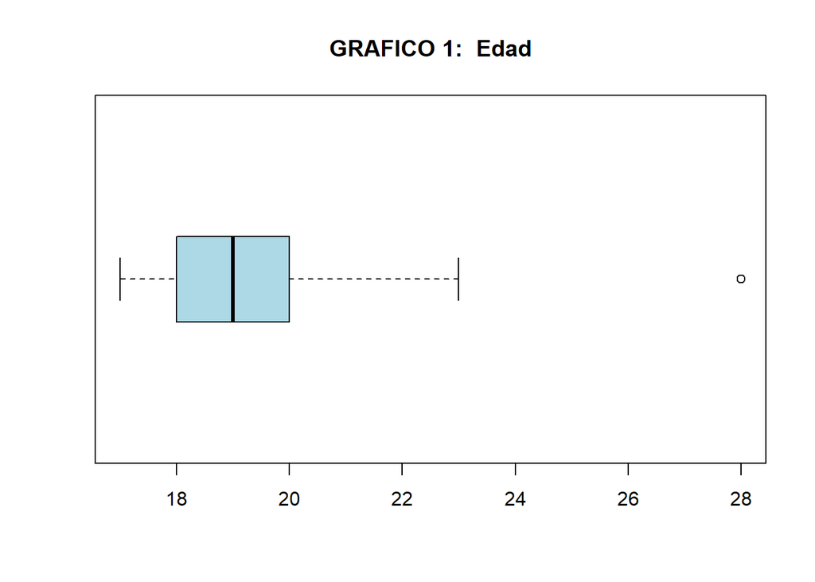

```r
 boxplot(Clima2$E,
        main = "GRAFICO 1:  Edad",horizontal = TRUE,
        boxwex = 0.5,col="lightblue")
```

Observamos que existe 1 dato atípico. Esto es normal dado que en un colectivo de estudiantes no necesariamente los que llevan un curso general son jóvenes. En este caso, la edad atípica es de 28 años. La mayoría se conglomera entre los 19 años

```r
cat('Moda:',round(Mode(Clima2$E),2),'\n')
```

```
## Moda: 19
```

```r
cat('Mediana:',round(median(Clima2$E),2),'\n')
```

```
## Mediana: 19
```

```r
cat('Desviación Estándar:',round(sd(Clima2$E),2),'\n')
```

```
## Desviación Estándar: 1.51
```

```r
cat('Rango:',round(range(Clima2$E),2),'\n')
```

```
## Rango: 17 28
```

```r
cat('Rango Intercuartil:',round(IQR(Clima2$E),2),'\n')
```

```
## Rango Intercuartil: 2
```

```r
cat('Coeficiente de Variación:', round((sd(Clima2$E)/mean(Clima2$E))*100,2),'\n')
```

```
## Coeficiente de Variación: 7.87
```

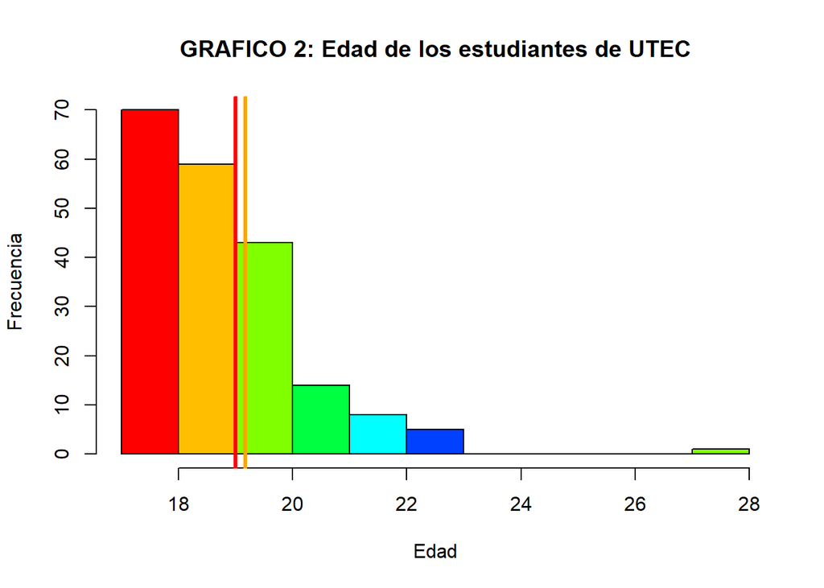

```r
hist1<-hist(Clima2$E,
            main="GRAFICO 2: Edad de los estudiantes de UTEC",
            col=rainbow(8),xlab="Edad",
            ylab="Frecuencia")
abline(v=mean(Clima2$E),
       col="orange",
       lwd=3)
abline(v=median(Clima2$E),
       col="blue",
       lwd=3)
abline(v=19,
       col="red",
       lwd=3)
```

### b. Nota del examen parcial de Comunicación:

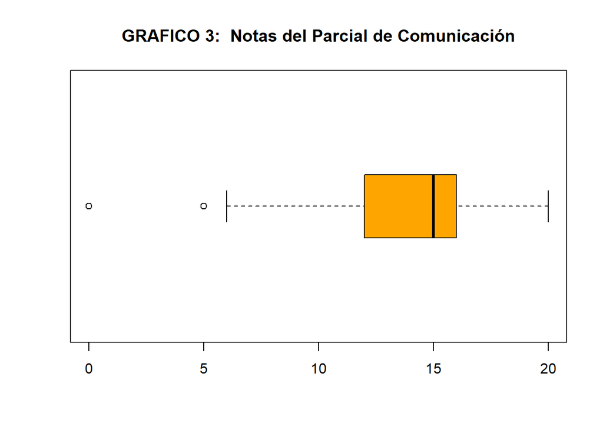

```r
 boxplot(Clima2$NPC,
        main = "GRAFICO 3:  Notas del Parcial de Comunicación",horizontal = TRUE,
        boxwex = 0.5,col="orange")
```

A partir de lo realizado existen 2 datos atípicos. Esto quiere decir existe 2 notas bajas en comparación con las demás, lo cual es viable porque se está trabajando con notas de estudiantes que si pueden llegar a tener las notas que tienen números atípicos, por lo que no lo eliminamos pero ya no determinaremos la media ya que no sería una medida adecuada.

```r
cat('Moda:',round(Mode(Clima2$NPC),2),'\n')
```

```
## Moda: 16
```

```r
cat('Mediana:',round(median(Clima2$NPC),2),'\n')
```

```
## Mediana: 15
```

```r
cat('Desviación Estándar:',round(sd(Clima2$NPC),2),'\n')
```

```
## Desviación Estándar: 5.13
```

```r
cat('Rango:',round(range(Clima2$NPC),2),'\n')
```

```
## Rango: 0 20
```

```r
cat('Rango Intercuartil:',round(IQR(Clima2$NPC),2),'\n')
```

```
## Rango Intercuartil: 4
```

```r
cat('Coeficiente de Variación:', round((sd(Clima2$NPC)/mean(Clima2$NPC))*100,2),'\n')
```

```
## Coeficiente de Variación: 38.14
```

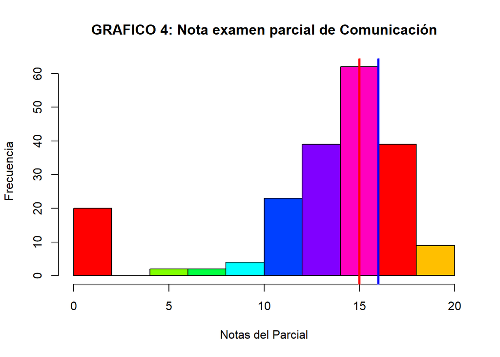

```r
hist1<-hist(Clima2$NPC,
            main="GRAFICO 4: Nota examen parcial de Comunicación",
            col=rainbow(8),xlab="Notas del Parcial",
            ylab="Frecuencia")
#abline(v=mean(Clima2$NPC),  #abline es sola para graficar
       #col="red",    #el color  que sera
       #lwd=3)        #el grosor de la linea
abline(v=median(Clima2$NPC),
       col="red",
       lwd=3)
abline(v=16,   #para la moda pones V de valor y defrente el numero de la moda ya que no hay una funcion para hallar la moda
       col="blue",
       lwd=3)
```

### c. Nota del examen final de Comunicación:

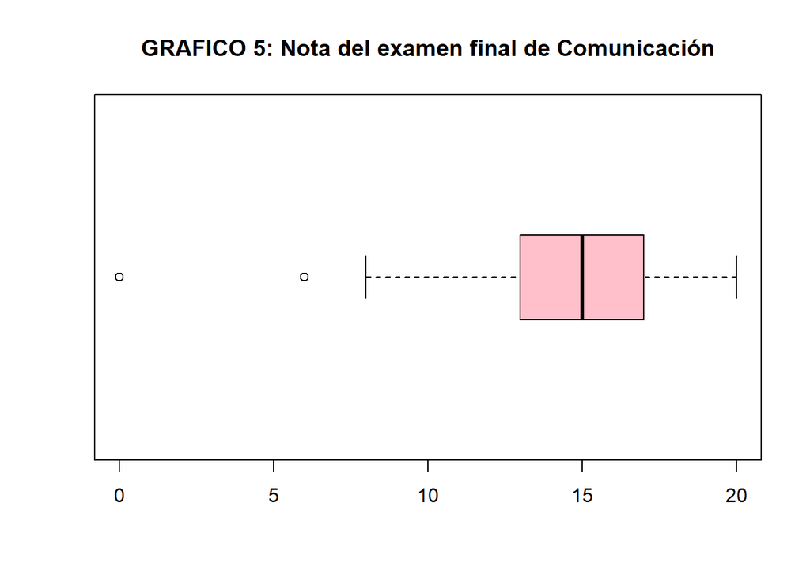

```r
 boxplot(Clima2$NFC,
        main = "GRAFICO 5: Nota del examen final de Comunicación",horizontal = TRUE,
        boxwex = 0.5,col="pink")
```

Existen 2 datos atípicos (0 y 6). Esto quiere decir que existe 2 notas bajas en comparación con las demás notas. Además, esto es viable porque se está trabajando con notas de estudiantes que, si pueden llegar a tener esas calificaciones que tienen números atípicos, por lo que no lo eliminamos, pero ya no determinaremos la media ya que no sería una medida adecuada.

```r
cat('Moda:',round(Mode(Clima2$NFC),2),'\n')
```

```
## Moda: 15
```

```r
#cat('Media:',round(mean(Clima2$NFC),2),'\n')
cat('Mediana:',round(median(Clima2$NFC),2),'\n')
```

```
## Mediana: 15
```

```r
cat('Desviación Estándar:',round(sd(Clima2$NFC),2),'\n')
```

```
## Desviación Estándar: 5.15
```

```r
cat('Rango:',round(range(Clima2$NFC),2),'\n')
```

```
## Rango: 0 20
```

```r
cat('Rango Intercuartil:',round(IQR(Clima2$NFC),2),'\n')
```

```
## Rango Intercuartil: 4
```

```r
cat('Coeficiente de Variación:', round((sd(Clima2$NFC)/mean(Clima2$NFC))*100,2),'\n')
```

```
## Coeficiente de Variación: 37.59
```

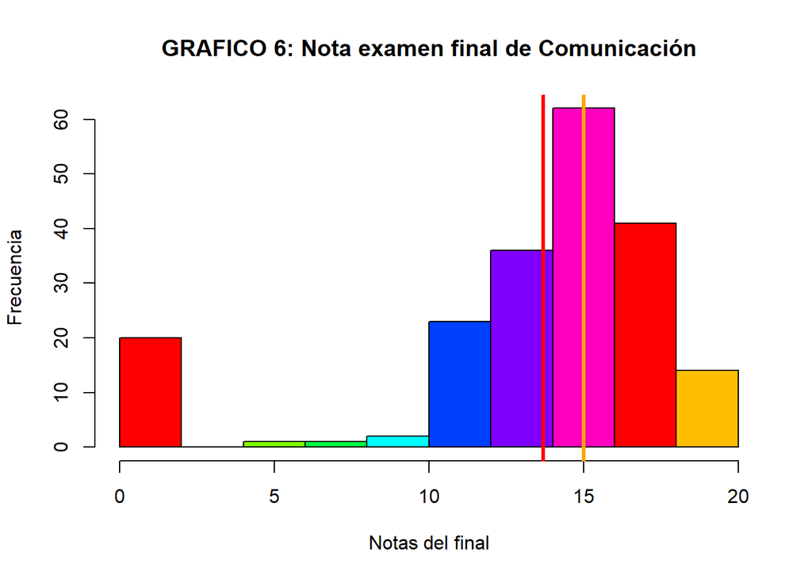

```r
hist1<-hist(Clima2$NFC,
            main="GRAFICO 6: Nota examen final de Comunicación",
            col=rainbow(8),xlab="Notas del final",
            ylab="Frecuencia")
abline(v=mean(Clima2$NFC),  #abline es sola para graficar
       col="red",    #el color  que sera
       lwd=3)        #el grosor de la linea
abline(v=median(Clima2$NFC),
       col="blue",
       lwd=3)
abline(v=15,   #para la moda pones V de valor y defrente el numero de la moda ya que no hay una funcion para hallar la moda
       col="orange",
       lwd=3)
```

### d. Nota del examen parcial de Introducción a la Mecánica:

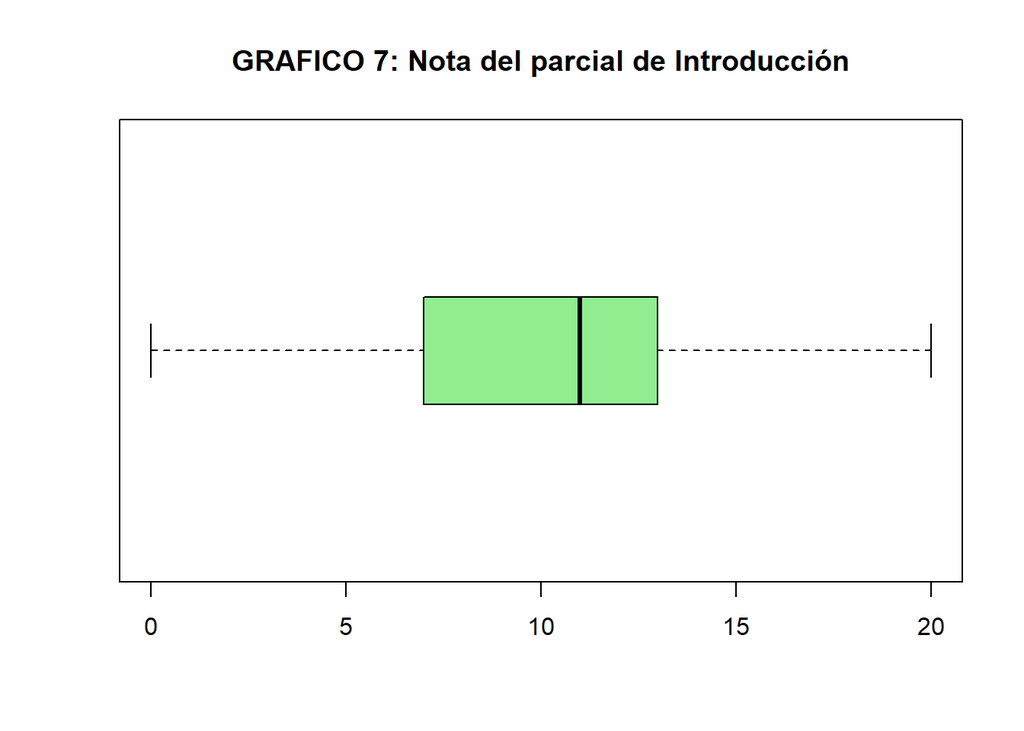

```r
 boxplot(Clima2$NPIM,
        main = "GRAFICO 7: Nota del parcial de Introducción",horizontal = TRUE,
        boxwex = 0.5,col="lightgreen")
```

No existe datos atípicos. Esto quiere decir que no existe observaciones que están alejadas del resto, por lo que en los descriptores numéricos podemos considerar a la media.

```r
cat('Moda:',round(Mode(Clima2$NPIM),2),'\n')
```

```
## Moda: 0
```

```r
cat('Media:',round(mean(Clima2$NPIM),2),'\n')
```

```
## Media: 9.56
```

```r
cat('Mediana:',round(median(Clima2$NPIM),2),'\n')
```

```
## Mediana: 11
```

```r
cat('Desviación Estándar:',round(sd(Clima2$NPIM),2),'\n')
```

```
## Desviación Estándar: 5.39
```

```r
cat('Rango:',round(range(Clima2$NPIM),2),'\n')
```

```
## Rango: 0 20
```

```r
cat('Rango Intercuartil:',round(IQR(Clima2$NPIM),2),'\n')
```

```
## Rango Intercuartil: 6
```

```r
cat('Coeficiente de Variación:', round((sd(Clima2$NPIM)/mean(Clima2$NPIM))*100,2),'\n')
```

```
## Coeficiente de Variación: 56.31
```

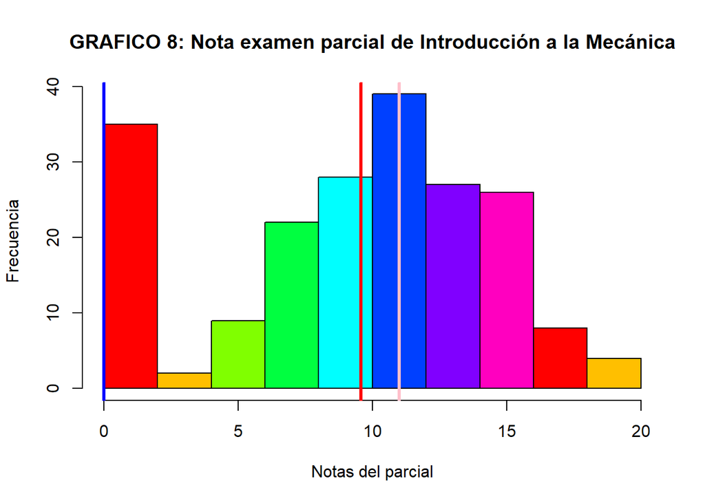

```r
hist1<-hist(Clima2$NPIM,
            main="GRAFICO 8: Nota examen parcial de Introducción a la Mecánica",
            col=rainbow(8),xlab="Notas del parcial",
            ylab="Frecuencia")
abline(v=mean(Clima2$NPIM),  #abline es sola para graficar
       col="red",    #el color  que sera
       lwd=3)        #el grosor de la linea
abline(v=median(Clima2$NPIM),
       col="pink",
       lwd=3)
abline(v=0,   #para la moda pones V de valor y defrente el numero de la moda ya que no hay una funcion para hallar la moda
       col="blue",
       lwd=3)
```

### e. Nota del examen final de Introducción a la Mecánica:

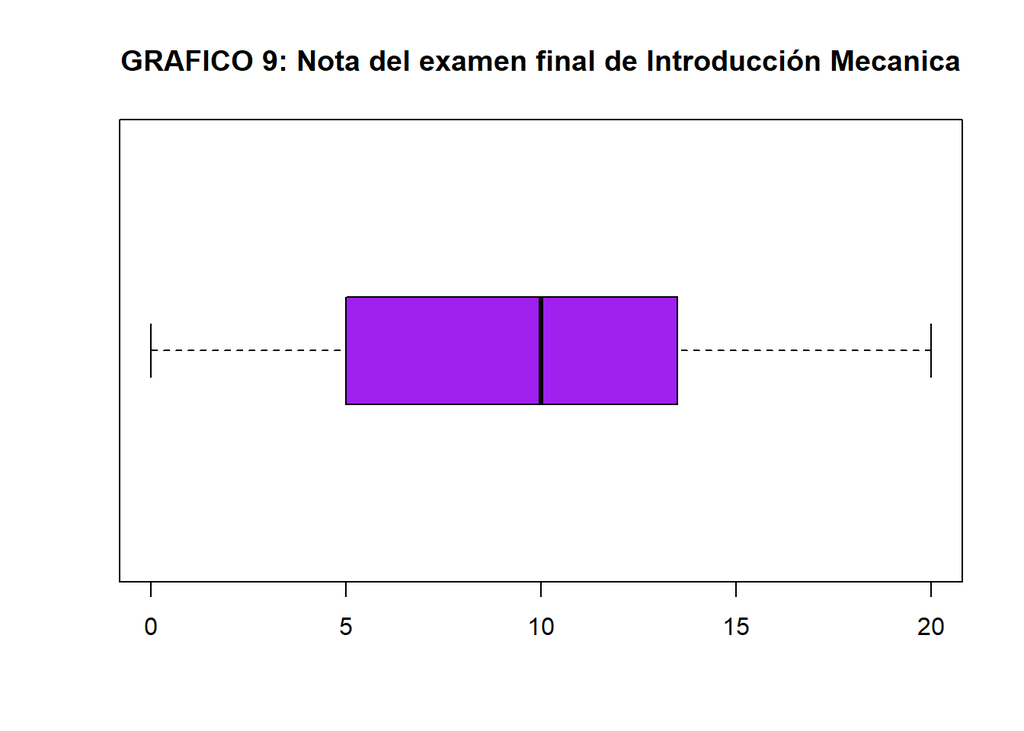

```r
 boxplot(Clima2$NFIM,
        main = "GRAFICO 9: Nota del examen final de Introducción Mecanica",horizontal = TRUE,
        boxwex = 0.5,col="purple")
```

No existe datos atipicos. Esto quiere decir que no existe observaciones que están alejadas del resto de los demás, por lo que en los descriptores numéricos podemos considerar a la media.

```r
cat('Moda:',round(Mode(Clima2$NFIM),2),'\n')
```

```
## Moda: 0
```

```r
cat('Media:',round(mean(Clima2$NFIM),2),'\n')
```

```
## Media: 9.06
```

```r
cat('Mediana:',round(median(Clima2$NFIM),2),'\n')
```

```
## Mediana: 10
```

```r
cat('Desviación Estándar:',round(sd(Clima2$NFIM),2),'\n')
```

```
## Desviación Estándar: 5.7
```

```r
cat('Rango:',round(range(Clima2$NFIM),2),'\n')
```

```
## Rango: 0 20
```

```r
cat('Rango Intercuartil:',round(IQR(Clima2$NFIM),2),'\n')
```

```
## Rango Intercuartil: 8.25
```

```r
cat('Coeficiente de Variación:', round((sd(Clima2$NFIM)/mean(Clima2$NFIM))*100,2),'\n')
```

```
## Coeficiente de Variación: 62.95
```

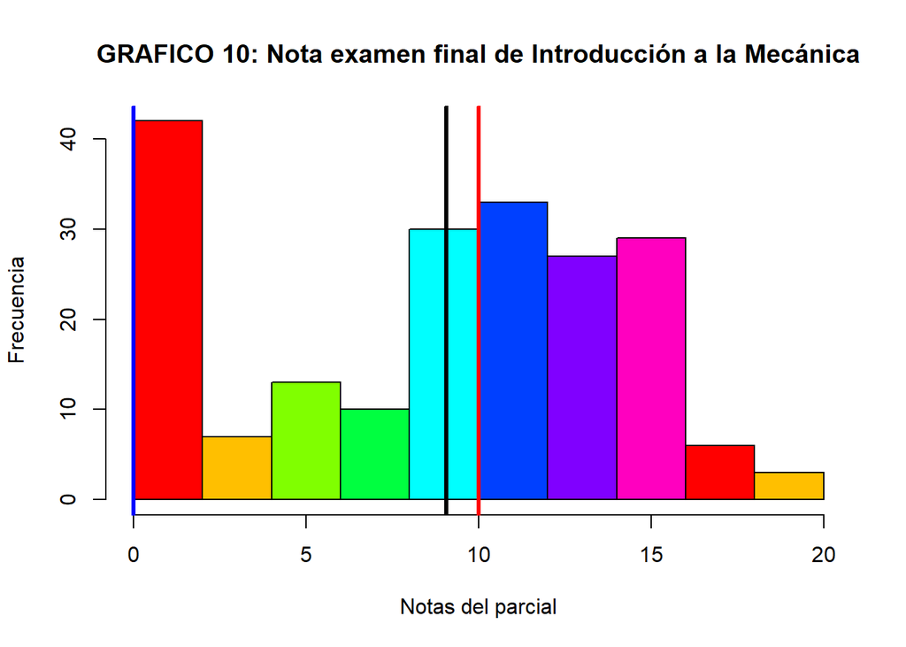

```r
hist1<-hist(Clima2$NFIM,
            main="GRAFICO 10: Nota examen final de Introducción a la Mecánica",
            col=rainbow(8),xlab="Notas del parcial",
            ylab="Frecuencia")
abline(v=mean(Clima2$NFIM),  #abline es sola para graficar
       col="black",    #el color  que sera
       lwd=3)        #el grosor de la linea
abline(v=median(Clima2$NFIM),
       col="red",
       lwd=3)
abline(v=0,   #para la moda pones V de valor y defrente el numero de la moda ya que no hay una funcion para hallar la moda
       col="blue",
       lwd=3)
```

## 3.2. Descriptores gráficos:

### a. Nota del examen parcial de Introducción a la Mecánica:

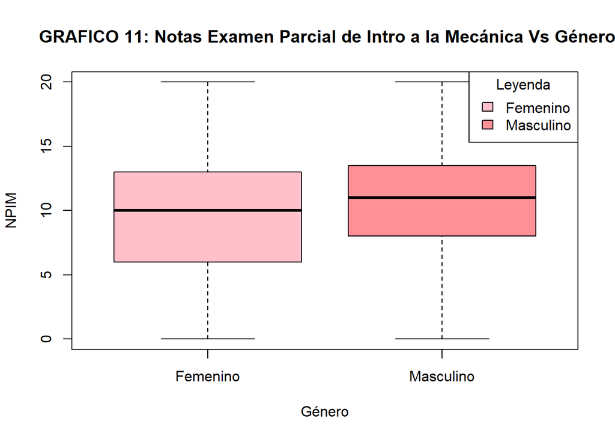

```r
boxplot(Clima2$NPIM ~ Clima2$G , ylab = "NPIM", xlab = "Género", col=colorRampPalette(c('pink','red'))(5),main=" GRAFICO 11: Notas Examen Parcial de Intro a la Mecánica Vs Género")
legend(x = "topright", legend = c("Femenino", "Masculino"), fill =colorRampPalette(c('pink','red'))(5),
       title = "Leyenda")
```

### b. Nota del examen parcial de Comunicación 2 por Género:

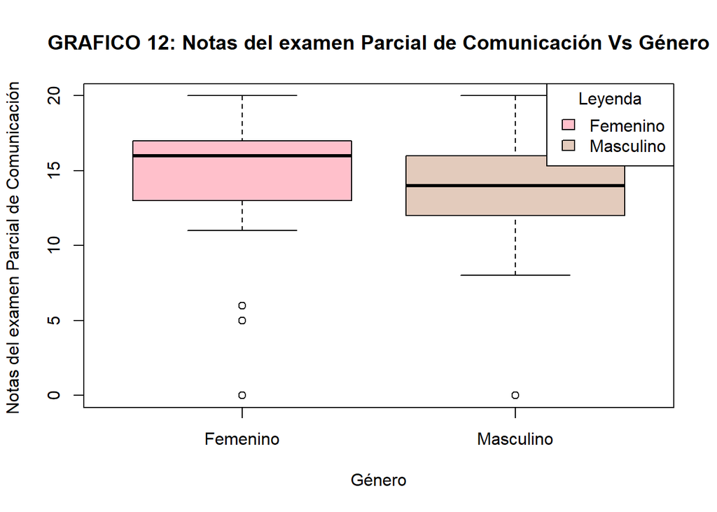

```r
boxplot(Clima2$NPC ~ Clima2$G , ylab = "Notas del examen Parcial de Comunicación ", xlab = "Género", col=colorRampPalette(c('pink','lightgreen'))(5),main="GRAFICO 12: Notas del examen Parcial de Comunicación Vs Género")
legend(x = "topright", legend = c("Femenino", "Masculino"), fill =colorRampPalette(c('pink','lightgreen'))(5),
       title = "Leyenda")
```

### c. Nota del examen final de Introducción a la Mecánica por Género:

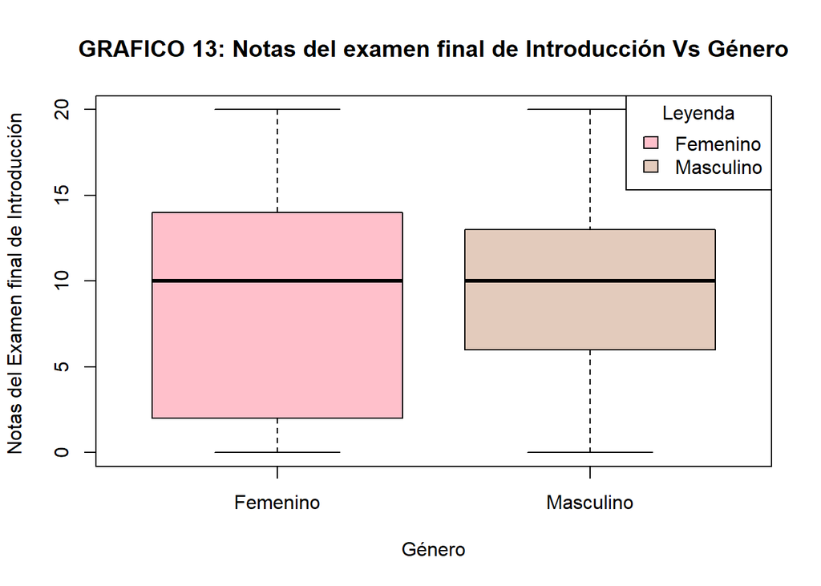

```r
boxplot(Clima2$NFIM ~ Clima2$G , ylab = "Notas del Examen final de Introducción ", xlab = "Género", col=colorRampPalette(c('pink','lightgreen'))(5),main="GRAFICO 13: Notas del examen final de Introducción Vs Género")
legend(x = "topright", legend = c("Femenino", "Masculino"), fill =colorRampPalette(c('pink','lightgreen'))(5),
       title = "Leyenda")
```

### d. Nota del examen final de Comunicación 2 por Género:

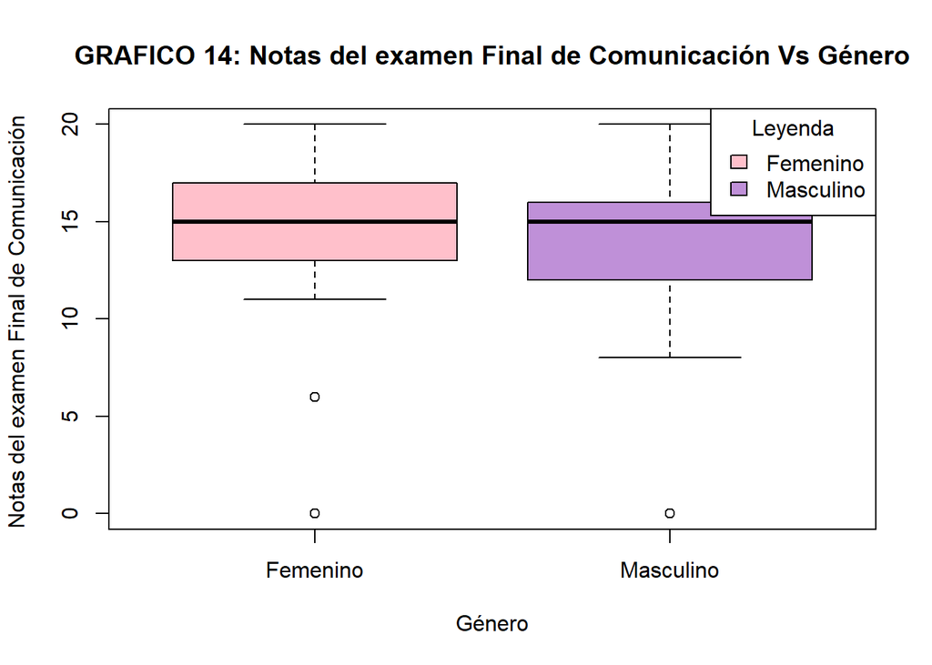

```r
boxplot(Clima2$NFC ~ Clima2$G , ylab = "Notas del examen Final de Comunicación ", xlab = "Género", col=colorRampPalette(c('pink','blue'))(5),main="GRAFICO 14: Notas del examen Final de Comunicación Vs Género")
legend(x = "topright", legend = c("Femenino", "Masculino"), fill =colorRampPalette(c('pink','blue'))(5),
       title = "Leyenda")
```

### e. Preferencia del Clima para dar una evaluación vs Género:

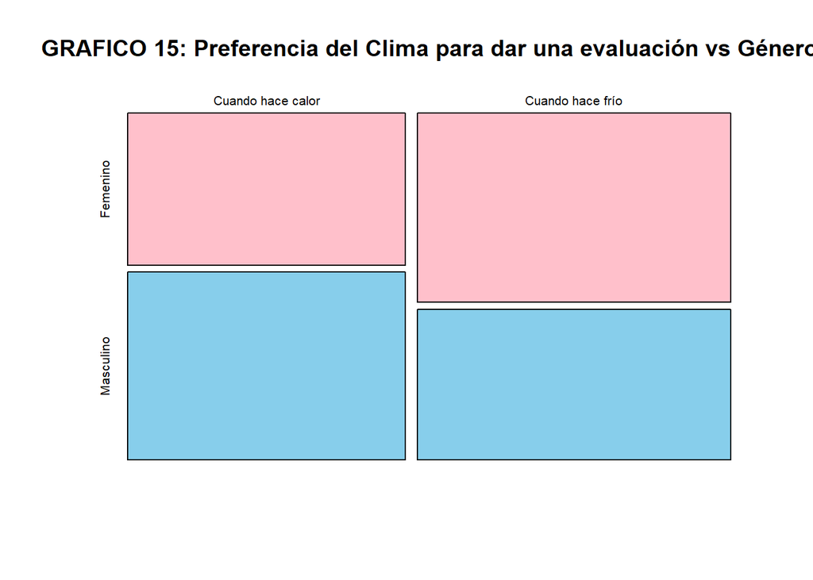

```r
mosaicplot(table(Clima2$PC,Clima2$G),
           col=c("pink","sky blue"),
           main="GRAFICO 15: Preferencia del Clima para dar una evaluación vs Género")
```

### f. Cómo afecta el calor en la concentración:

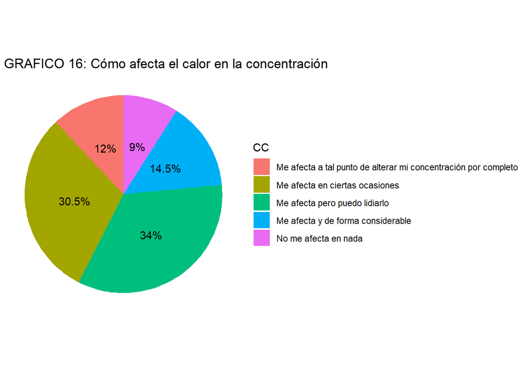

```r
val_1 <- Clima2 %>%
  group_by(CC) %>%
  count() %>%
  ungroup() %>%
  mutate(val_1=`n`/sum(`n`) * 100)

ggplot(val_1, aes(x=1, y=val_1, fill=CC)) +
        geom_bar(stat="identity") +
        geom_text(aes(label = paste0(round(val_1,1),"%")),
                  position = position_stack(vjust = 0.5)) +
        coord_polar(theta = "y") +
        theme_void()+labs(x = "Medidas en frío",
     y = "Frecuencia", title =" GRAFICO 16: Cómo afecta el calor en la concentración ")
```

De los encuestados, un gran porcentaje afirma que puede lidiar con el calor y que no afecta de forma significativa en su concentración al rendir una evaluación:

### g. Cómo afecta el frio en la concentración:

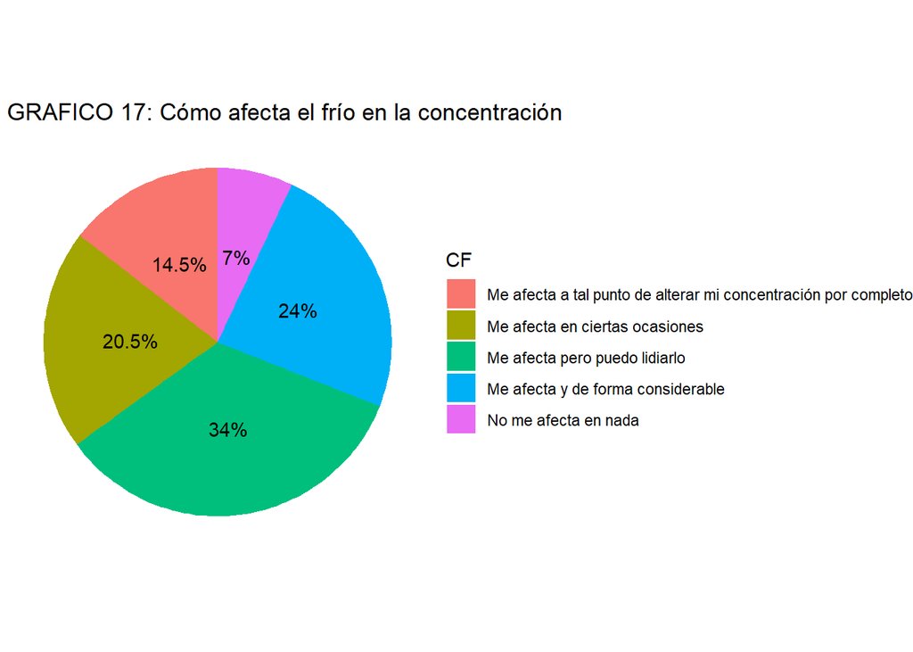

```r
val_2 <- Clima2 %>%
  group_by(CF) %>%
  count() %>%
  ungroup() %>%
  mutate(val_2=`n`/sum(`n`) * 100)

ggplot(val_2, aes(x=1, y=val_2, fill=CF)) +
        geom_bar(stat="identity") +
        geom_text(aes(label = paste0(round(val_2,1),"%")),
                  position = position_stack(vjust = 0.5)) +
        coord_polar(theta = "y") +
        theme_void()+labs(x = "Medidas en frío",
     y = "Frecuencia", title =" GRAFICO 17: Cómo afecta el frío en la concentración ")
```

De los encuestados, un gran porcentaje afirma que puede lidiar con el frío y que no afecta de forma significativa en su concentración al rendir una evaluación

### h. Medidas para enfrentar el frío en una evaluación:

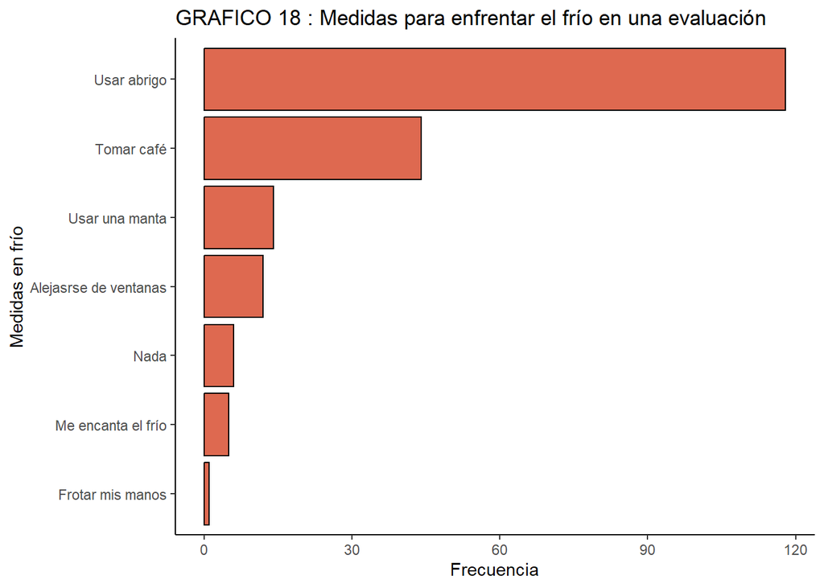

```r
val_3<- Clima2%>% count(`MF`)
d<-val_3 %>% arrange(n) %>% mutate(`MF` = factor(`MF`, level = `MF`)) %>%  ggplot(aes(`MF`,n)) + geom_bar(stat = "identity", fill = "#DE6950", color = "black") + labs(x = "Medidas en frío",
     y = "Frecuencia", title = "GRAFICO 18 : Medidas para enfrentar el frío en una evaluación")+ coord_flip()
d+theme_classic()
```

Para enfrentar el frío en épocas de evaluación, una gran mayoría usa abrigo, mientras que un número reducido disfruta de ella.

### i. Medidas para enfrentar el calor en una evaluación:

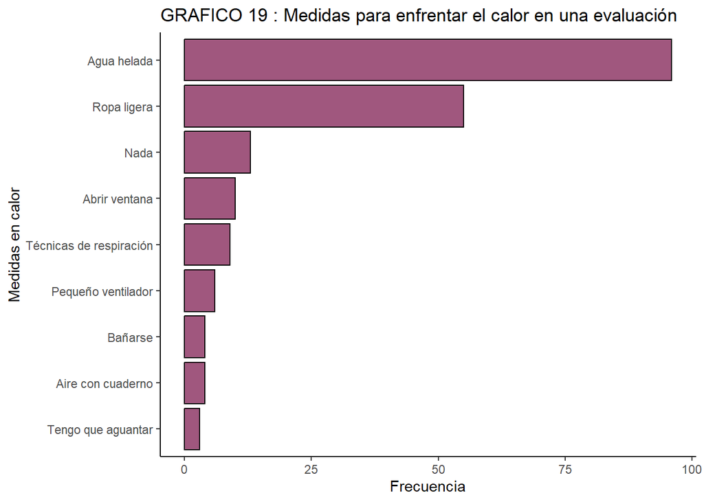

```r
val_4<- Clima2%>% count(`MC`)
d<-val_4 %>% arrange(n) %>% mutate(`MC` = factor(`MC`, level = `MC`)) %>%  ggplot(aes(`MC`,n)) + geom_bar(stat = "identity", fill = "#A0577E", color = "black") + labs(x = "Medidas en calor",
     y = "Frecuencia", title = "GRAFICO 19 : Medidas para enfrentar el calor en una evaluación")+ coord_flip()
d+theme_classic()
```

### j. Sensaciones que genera el calor en una evaluación:

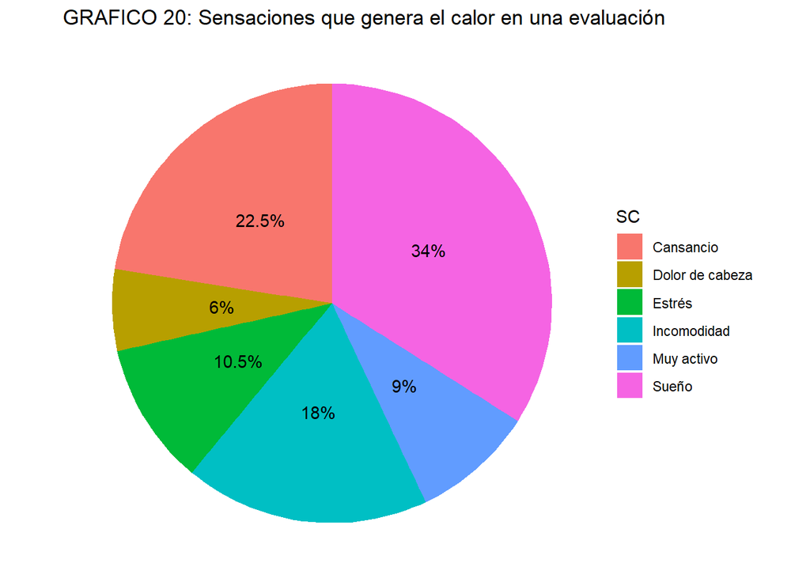

```r
val_5 <- Clima2 %>%
  group_by(SC) %>%
  count() %>%
  ungroup() %>%
  mutate(val_5=`n`/sum(`n`) * 100)

ggplot(val_5, aes(x=1, y=val_5, fill=SC)) +
        geom_bar(stat="identity") +
        geom_text(aes(label = paste0(round(val_5,1),"%")),
                  position = position_stack(vjust = 0.5)) +
        coord_polar(theta = "y") +
        theme_void()+labs(x = "Medidas en frío",
     y = "Frecuencia", title =" GRAFICO 20: Sensaciones que genera el calor en una evaluación ")
```

### k. Sensaciones que genera el frio en una evaluación:

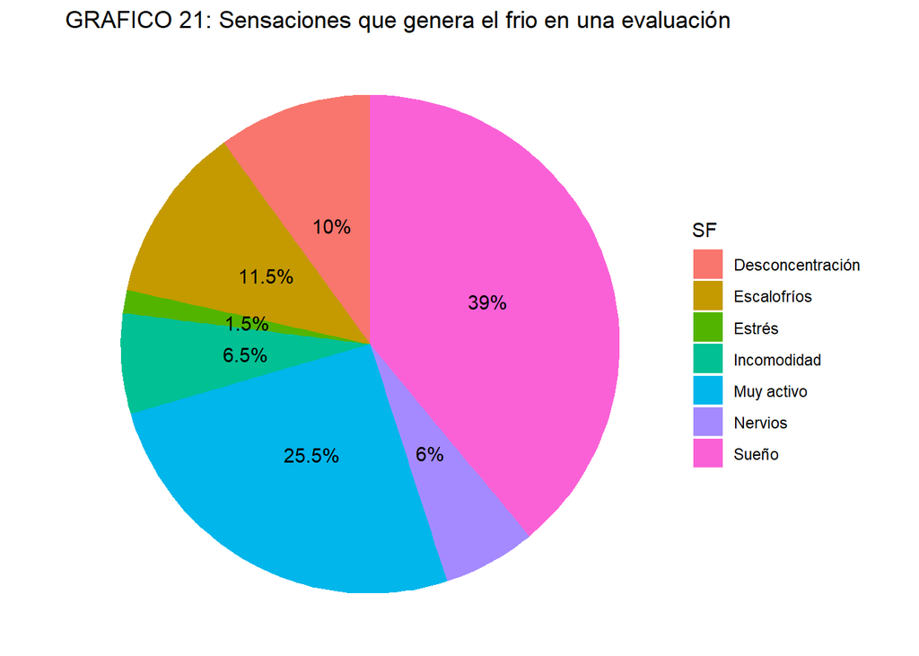

```r
val_6 <- Clima2 %>%
  group_by(SF) %>%
  count() %>%
  ungroup() %>%
  mutate(val_6=`n`/sum(`n`) * 100)

ggplot(val_6, aes(x=1, y=val_6, fill=SF)) +
        geom_bar(stat="identity") +
        geom_text(aes(label = paste0(round(val_6,1),"%")),
                  position = position_stack(vjust = 0.5)) +
        coord_polar(theta = "y") +
        theme_void()+labs(x = "Medidas en frío",
     y = "Frecuencia", title =" GRAFICO 21: Sensaciones que genera el frio en una evaluación ")
```

## 3.3. Modelos de Regresión:

### a. Relación entre la Edad y la Nota del examen Parcial de Intro a la Mecánica:

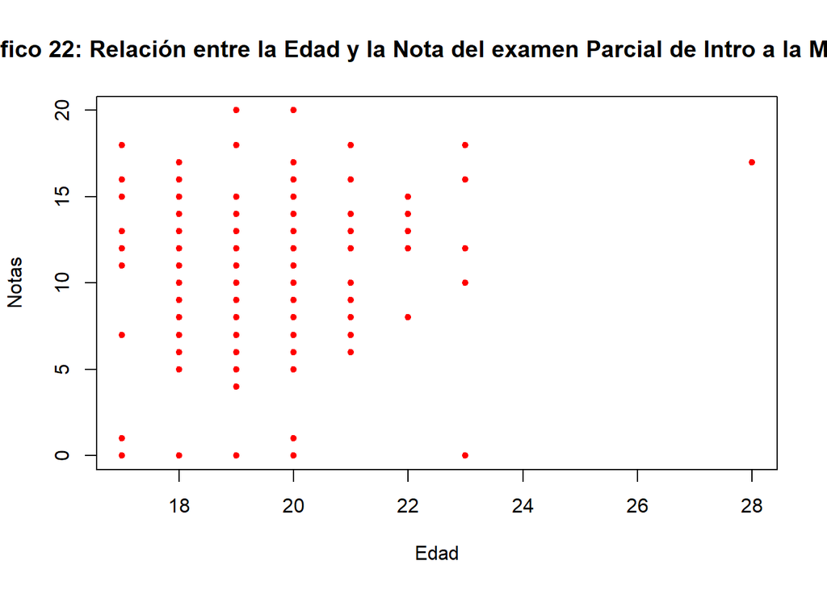

```r
plot(Clima2$E,Clima2$NPIM,main = "Gráfico 22: Relación entre la Edad y la Nota del examen Parcial de Intro a la Mecánica", xlab= "Edad", ylab= "Notas", col= "red",pch=20)
```

```r
resultado <- lm(Clima2$NPIM~Clima2$E)

round(cor(Clima2$E,Clima2$NPIM, use = "complete.obs"),digits=2)
```

```
## [1] 0.19
```

```r
summary(resultado)
```

```
##
## Call:
## lm(formula = Clima2$NPIM ~ Clima2$E)
##
## Residuals:
##      Min       1Q   Median       3Q      Max
## -12.1007  -2.7861   0.8881   3.5538  10.5510
##
## Coefficients:
##             Estimate Std. Error t value Pr(>|t|)
## (Intercept)  -3.1467     4.7955  -0.656  0.51247
## Clima2$E      0.6629     0.2493   2.659  0.00848 **
## ---
## Signif. codes:  0 '***' 0.001 '**' 0.01 '*' 0.05 '.' 0.1 ' ' 1
##
## Residual standard error: 5.306 on 198 degrees of freedom
## Multiple R-squared:  0.03447,    Adjusted R-squared:  0.0296
## F-statistic:  7.07 on 1 and 198 DF,  p-value: 0.008481
```

La correlación entre ambas variables es de 0.19 lo que nos indica que es una correlación muy baja. En este caso observamos que nuestra ecuación sería y=0.66∗x-3.15. Además la tendencia que sigue el gráfico nos da ha entender que mientras mayor sea la edad mayor es la NPIM.

### b. Relación entre la Edad y la Nota del examen Final de Introducción a la Mecánica:

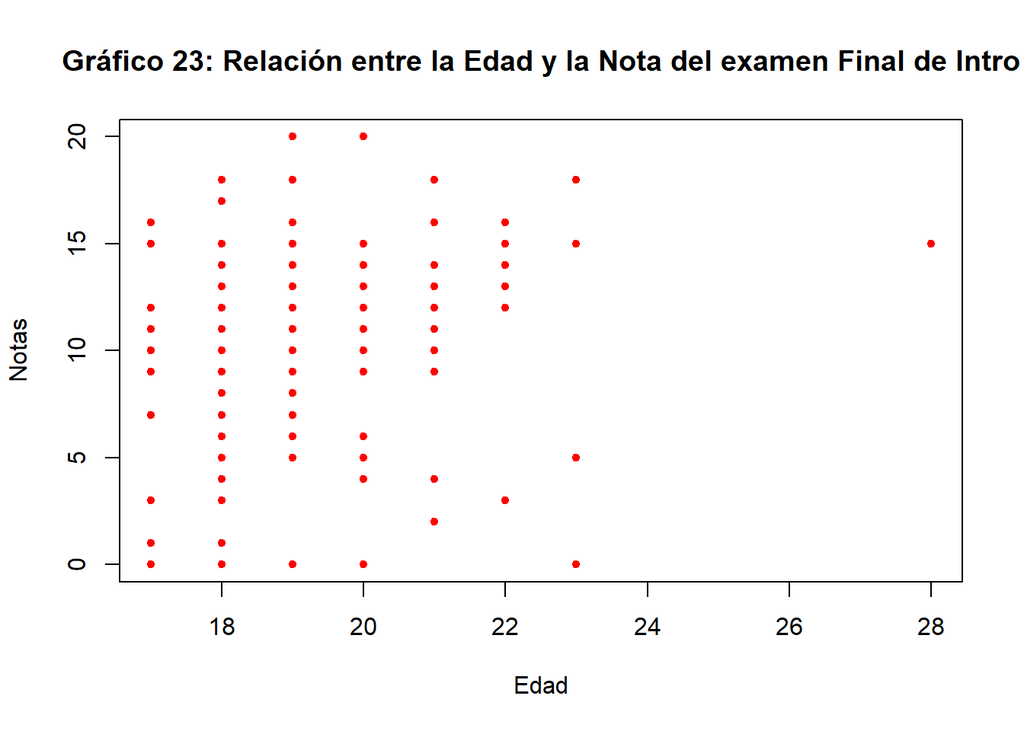

```r
plot(Clima2$E,Clima2$NFIM,main = "Gráfico 23: Relación entre la Edad y la Nota del examen Final de Intro", xlab= "Edad", ylab= "Notas", col= "red",pch=20)
```

```r
resultado <- lm(Clima2$NFIM~Clima2$E)

round(cor(Clima2$E,Clima2$NFIM, use = "complete.obs"),digits=2)
```

```
## [1] 0.2
```

```r
summary(resultado)
```

```
##
## Call:
## lm(formula = Clima2$NFIM ~ Clima2$E)
##
## Residuals:
##     Min      1Q  Median      3Q     Max
## -11.931  -4.178   1.196   4.071  11.071
##
## Coefficients:
##             Estimate Std. Error t value Pr(>|t|)
## (Intercept)  -5.3316     5.0650  -1.053  0.29379
## Clima2$E      0.7505     0.2633   2.850  0.00483 **
## ---
## Signif. codes:  0 '***' 0.001 '**' 0.01 '*' 0.05 '.' 0.1 ' ' 1
##
## Residual standard error: 5.604 on 198 degrees of freedom
## Multiple R-squared:  0.03941,    Adjusted R-squared:  0.03456
## F-statistic: 8.123 on 1 and 198 DF,  p-value: 0.004833
```

La correlación entre ambas variables es de 0.2 lo que nos indica que es una correlación muy baja. En este caso observamos que nuestra ecuación sería y=0.75∗x-5.33. Además la tendencia que sigue el gráfico nos da ha entender que mientras mayor sea la edad mayor es la NFIM.

### c. Relación entre la Edad y la Nota del examen Parcial de Comu2:

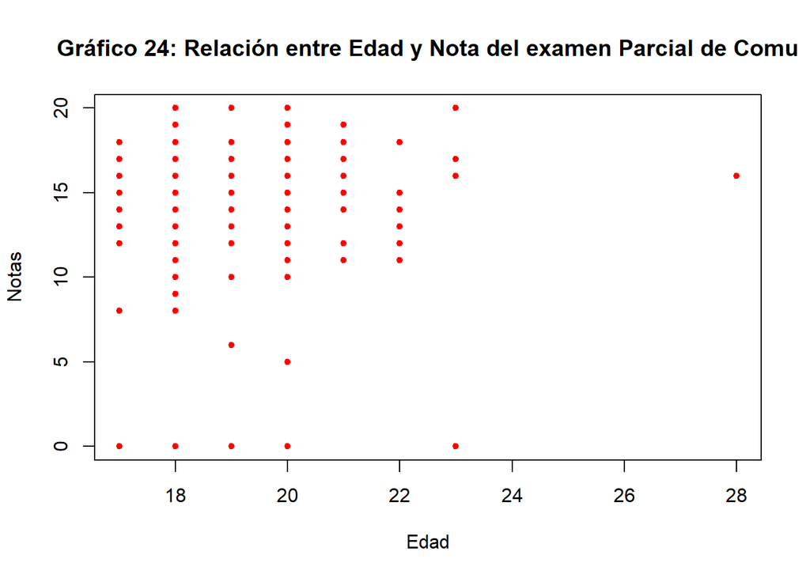

```r
plot(Clima2$E,Clima2$NPC,main = "Gráfico 24: Relación entre Edad y Nota del examen Parcial de Comu", xlab= "Edad", ylab= "Notas", col= "red",pch=20)
```

```r
resultado <- lm(Clima2$NPC~Clima2$E)

round(cor(Clima2$E,Clima2$NPC, use = "complete.obs"),digits=2)
```

```
## [1] 0.16
```

```r
summary(resultado)
```

```
##
## Call:
## lm(formula = Clima2$NPC ~ Clima2$E)
##
## Residuals:
##      Min       1Q   Median       3Q      Max
## -15.5735  -0.9002   1.4843   3.2154   7.2154
##
## Coefficients:
##             Estimate Std. Error t value Pr(>|t|)
## (Intercept)   2.7448     4.5818   0.599   0.5498
## Clima2$E      0.5578     0.2382   2.341   0.0202 *
## ---
## Signif. codes:  0 '***' 0.001 '**' 0.01 '*' 0.05 '.' 0.1 ' ' 1
##
## Residual standard error: 5.069 on 198 degrees of freedom
## Multiple R-squared:  0.02694,    Adjusted R-squared:  0.02203
## F-statistic: 5.482 on 1 and 198 DF,  p-value: 0.0202
```

La correlación entre ambas variables es de 0.16 lo que nos indica que es una correlación muy baja. En este caso observamos que nuestra ecuación sería y=0.56∗x+2.75. Además la tendencia que sigue el gráfico nos da ha entender que mientras mayor sea la edad mayor es la NPC.

### d. Relación entre la Edad y la Nota del examen Final de Comu2:

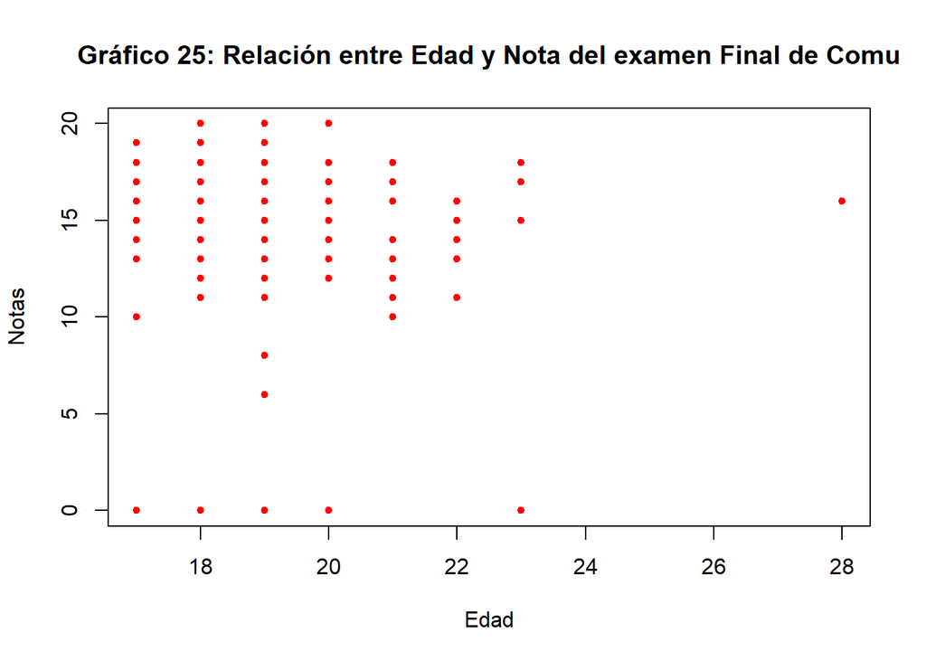

```r
plot(Clima2$E,Clima2$NFC,main = "Gráfico 25: Relación entre Edad y Nota del examen Final de Comu", xlab= "Edad", ylab= "Notas", col= "red",pch=20)
```

```r
resultado <- lm(Clima2$NFC~Clima2$E)

round(cor(Clima2$E,Clima2$NFC, use = "complete.obs"),digits=2)
```

```
## [1] 0.12
```

```r
summary(resultado)
```

```
##
## Call:
## lm(formula = Clima2$NFC ~ Clima2$E)
##
## Residuals:
##     Min      1Q  Median      3Q     Max
## -15.238  -1.221   1.279   3.182   6.779
##
## Coefficients:
##             Estimate Std. Error t value Pr(>|t|)
## (Intercept)   5.9604     4.6321   1.287   0.1997
## Clima2$E      0.4034     0.2408   1.675   0.0955 .
## ---
## Signif. codes:  0 '***' 0.001 '**' 0.01 '*' 0.05 '.' 0.1 ' ' 1
##
## Residual standard error: 5.125 on 198 degrees of freedom
## Multiple R-squared:  0.01397,    Adjusted R-squared:  0.00899
## F-statistic: 2.805 on 1 and 198 DF,  p-value: 0.09553
```

La correlación entre ambas variables es de 0.12 lo que nos indica que es una correlación muy baja. En este caso observamos que nuestra ecuación sería y=0.40∗x+5.96. Además la tendencia que sigue el gráfico nos da ha entender que mientras mayor sea la edad mayor es la NFC.